# Análisis Predictivo en Business Intelligence: ejemplos en Python

Autor/a

Fernando Salcedo Mejía Eco, Ms

Fecha de publicación

1 de febrero de 2026

Este notebook desarrolla en Python los casos de estudio de la presentación **Análisis Predictivo en Business Intelligence**. Los datos son simulados con una semilla fija por el script `simular_datos.R`, que los guarda en la carpeta `datos/`. La versión en R de este notebook lee los mismos archivos, por lo que ambos trabajan con exactamente los mismos datos.

```python
import matplotlib.pyplot as plt
import numpy as np
import pandas as pd
import seaborn as sns
import statsmodels.formula.api as smf
from IPython.display import display
from sklearn.cluster import KMeans
from sklearn.ensemble import RandomForestClassifier
from sklearn.metrics import (
    accuracy_score,
    confusion_matrix,
    f1_score,
    precision_score,
    recall_score,
    roc_auc_score,
    roc_curve,
    silhouette_score,
)
from sklearn.model_selection import train_test_split
from sklearn.preprocessing import StandardScaler
from sklearn.tree import DecisionTreeClassifier, export_text, plot_tree

sns.set_theme(style="whitegrid", font_scale=1.1)
pd.set_option("display.precision", 3)


def formato_usd(x):
    """Formatea un número con separador de miles en punto."""
    return f"{x:,.0f}".replace(",", ".")
```

# 1 Caso 1. Estimación y pronóstico de la demanda

La gerencia de una tienda de electrónica quiere ajustar los precios de sus cinco productos estrella para el próximo trimestre. Para anticipar el efecto en las ventas se estima la **elasticidad precio de la demanda** de cada producto con un modelo log-log:

$$\ln(Q) = \beta_1 + \beta_2 \ln(P) + \varepsilon, \qquad E_p = \beta_2$$

## 1.1 Datos

Ventas mensuales de cada producto entre 2016 y 2023.

```python
ventas = pd.read_csv("datos/ventas_electronica.csv", parse_dates=["fecha"])
ventas.head()
```

|  | producto | fecha | precio | cantidad |
| --- | --- | --- | --- | --- |
| 0 | Audífonos | 2016-01-01 | 85.16 | 4768 |
| 1 | Audífonos | 2016-02-01 | 70.28 | 8011 |
| 2 | Audífonos | 2016-03-01 | 81.35 | 4688 |
| 3 | Audífonos | 2016-04-01 | 79.19 | 4429 |
| 4 | Audífonos | 2016-05-01 | 73.85 | 7937 |

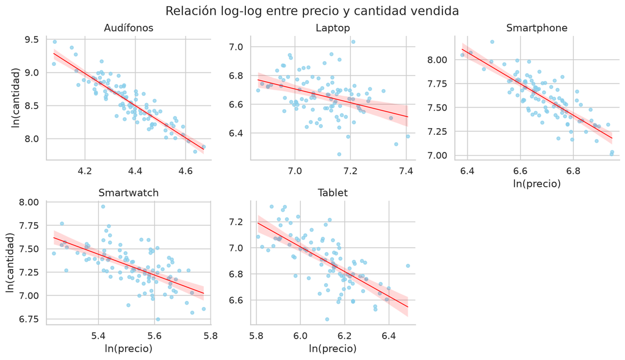

```python
ventas_log = ventas.assign(
    ln_precio=np.log(ventas["precio"]), ln_cantidad=np.log(ventas["cantidad"])
)

g = sns.lmplot(
    data=ventas_log,
    x="ln_precio",
    y="ln_cantidad",
    col="producto",
    col_wrap=3,
    height=3.2,
    aspect=1.2,
    facet_kws={"sharex": False, "sharey": False},
    scatter_kws={"color": "skyblue", "alpha": 0.7, "s": 18},
    line_kws={"color": "red", "linewidth": 1},
)
g.set_titles("{col_name}")
g.set_axis_labels("ln(precio)", "ln(cantidad)")
g.figure.suptitle("Relación log-log entre precio y cantidad vendida", y=1.02)
plt.show()
```

## 1.2 Estimación de la elasticidad

Se estima una regresión log-log para cada producto. El coeficiente de $\ln(P)$ es la elasticidad.

```python
filas = []
for producto, datos in ventas.groupby("producto"):
    modelo = smf.ols("np.log(cantidad) ~ np.log(precio)", data=datos).fit()
    termino = "np.log(precio)"
    ic = modelo.conf_int().loc[termino]
    filas.append({
        "producto": producto,
        "elasticidad": modelo.params[termino],
        "conf_low": ic[0],
        "conf_high": ic[1],
        "p_value": modelo.pvalues[termino],
        "r2": modelo.rsquared,
    })

elasticidades = pd.DataFrame(filas)
elasticidades.round(3)
```

|  | producto | elasticidad | conf_low | conf_high | p_value | r2 |
| --- | --- | --- | --- | --- | --- | --- |
| 0 | Audífonos | -2.432 | -2.675 | -2.189 | 0.0 | 0.808 |
| 1 | Laptop | -0.477 | -0.715 | -0.238 | 0.0 | 0.143 |
| 2 | Smartphone | -1.643 | -1.890 | -1.396 | 0.0 | 0.650 |
| 3 | Smartwatch | -1.112 | -1.403 | -0.821 | 0.0 | 0.380 |
| 4 | Tablet | -0.946 | -1.142 | -0.750 | 0.0 | 0.493 |

Todas las elasticidades son negativas y significativas, como predice la **ley de la demanda**. Por ejemplo, para los audífonos un aumento del 1 % en el precio reduce la cantidad vendida en cerca de 2.4 %.

## 1.3 Del modelo a la decisión de precios

Como el ingreso es $I = P \cdot Q$ y $Q \propto P^{E_p}$, el ingreso varía según $P^{1 + E_p}$:

- **Demanda elástica** ($E_p < -1$): bajar el precio **aumenta** el ingreso.
- **Demanda inelástica** ($-1 < E_p < 0$): subir el precio **aumenta** el ingreso.

```python
ep = elasticidades["elasticidad"]
pd.DataFrame({
    "producto": elasticidades["producto"],
    "elasticidad": ep.round(2),
    "tipo": np.where(ep < -1, "Elástica", "Inelástica"),
    "Δ% ingreso si el precio sube 5 %": ((1.05 ** (1 + ep) - 1) * 100).round(1),
    "Δ% ingreso si el precio baja 5 %": ((0.95 ** (1 + ep) - 1) * 100).round(1),
    "recomendacion": np.where(ep < -1, "Bajar precio", "Subir precio"),
})
```

|  | producto | elasticidad | tipo | Δ% ingreso si el precio sube 5 % | Δ% ingreso si el precio baja 5 % | recomendacion |
| --- | --- | --- | --- | --- | --- | --- |
| 0 | Audífonos | -2.43 | Elástica | -6.7 | 7.6 | Bajar precio |
| 1 | Laptop | -0.48 | Inelástica | 2.6 | -2.6 | Subir precio |
| 2 | Smartphone | -1.64 | Elástica | -3.1 | 3.4 | Bajar precio |
| 3 | Smartwatch | -1.11 | Elástica | -0.5 | 0.6 | Bajar precio |
| 4 | Tablet | -0.95 | Inelástica | 0.3 | -0.3 | Subir precio |

Antes de decidir conviene mirar los intervalos de confianza: para Smartwatch y Tablet el intervalo incluye $E_p = -1$, por lo que no se puede afirmar si la demanda es elástica o inelástica y el efecto de un cambio de precio sobre el ingreso es pequeño e incierto.

# 2 Caso 2. Fuga de clientes (churn)

Una empresa de telecomunicaciones quiere decidir **a qué clientes dirigir una campaña de retención**. Se comparan tres modelos de clasificación: logit, árbol de clasificación y random forest.

## 2.1 Datos

```python
telco = pd.read_csv("datos/telco_churn.csv")
# Mensual como categoría de referencia
telco["contrato"] = pd.Categorical(
    telco["contrato"], categories=["Mensual", "Anual", "Bianual"]
)

telco.head()  # churn: 1 = Fuga, 0 = Permanece
```

|  | id_cliente | antiguedad | cargo_mensual | contrato | llamadas_soporte | pago_electronico | churn | conjunto |
| --- | --- | --- | --- | --- | --- | --- | --- | --- |
| 0 | 1 | 38 | 52.2 | Bianual | 1 | 0 | 0 | entrenamiento |
| 1 | 2 | 45 | 119.3 | Anual | 2 | 0 | 0 | entrenamiento |
| 2 | 3 | 36 | 98.6 | Mensual | 1 | 1 | 1 | entrenamiento |
| 3 | 4 | 48 | 59.7 | Bianual | 3 | 0 | 0 | entrenamiento |
| 4 | 5 | 5 | 50.0 | Anual | 3 | 0 | 0 | entrenamiento |

```python
(
    telco.groupby("contrato", observed=True)
    .agg(clientes=("churn", "size"), tasa_fuga=("churn", "mean"))
    .assign(tasa_fuga=lambda d: (d["tasa_fuga"] * 100).round(1))
)
```

| contrato | clientes | tasa_fuga |
| --- | --- | --- |
| Mensual | 2706 | 29.0 |
| Anual | 1261 | 14.0 |
| Bianual | 1033 | 7.9 |

La tasa de fuga general es de 20.8 %. Los clientes con contrato mensual se van mucho más que los de contratos largos.

## 2.2 Entrenamiento y prueba

Partición estratificada: 70 % para entrenar y 30 % para evaluar, con la misma proporción de fuga en ambos conjuntos. La partición viene definida en la columna `conjunto` de los datos, para que los resultados coincidan con la versión en R. Así se haría desde cero con scikit-learn:

```python
entrenamiento, prueba = train_test_split(
    telco, train_size=0.7, stratify=telco["churn"], random_state=2026
)
```

```python
entrenamiento = telco[telco["conjunto"] == "entrenamiento"]
prueba = telco[telco["conjunto"] == "prueba"]

(
    telco.groupby("conjunto")
    .agg(clientes=("churn", "size"), tasa_fuga=("churn", "mean"))
    .assign(tasa_fuga=lambda d: (d["tasa_fuga"] * 100).round(1))
)
```

| conjunto | clientes | tasa_fuga |
| --- | --- | --- |
| entrenamiento | 3500 | 20.8 |
| prueba | 1500 | 20.9 |

scikit-learn necesita variables numéricas, así que el contrato se codifica con variables *dummy* (una columna por categoría) para el árbol y el random forest.

```python
predictores = ["antiguedad", "cargo_mensual", "contrato", "llamadas_soporte", "pago_electronico"]

def matriz_x(datos):
    return pd.get_dummies(datos[predictores], columns=["contrato"], dtype=int)

X_entrenamiento, X_prueba = matriz_x(entrenamiento), matriz_x(prueba)
y_entrenamiento, y_prueba = entrenamiento["churn"], prueba["churn"]

X_entrenamiento.head()
```

|  | antiguedad | cargo_mensual | llamadas_soporte | pago_electronico | contrato_Mensual | contrato_Anual | contrato_Bianual |
| --- | --- | --- | --- | --- | --- | --- | --- |
| 0 | 38 | 52.2 | 1 | 0 | 0 | 0 | 1 |
| 1 | 45 | 119.3 | 2 | 0 | 0 | 1 | 0 |
| 2 | 36 | 98.6 | 1 | 1 | 1 | 0 | 0 |
| 3 | 48 | 59.7 | 3 | 0 | 0 | 0 | 1 |
| 4 | 5 | 50.0 | 3 | 0 | 0 | 1 | 0 |

## 2.3 Regresión logística (logit)

Se usa `statsmodels`, que entrega la tabla de coeficientes con errores estándar y valores p. El contrato mensual es la categoría de referencia.

```python
logit = smf.logit(
    "churn ~ antiguedad + cargo_mensual + C(contrato, Treatment('Mensual'))"
    " + llamadas_soporte + pago_electronico",
    data=entrenamiento,
).fit(disp=False)
print(logit.summary())
```

```
                           Logit Regression Results
==============================================================================
Dep. Variable:                  churn   No. Observations:                 3500
Model:                          Logit   Df Residuals:                     3493
Method:                           MLE   Df Model:                            6
Date:                Wed, 04 Nov 2026   Pseudo R-squ.:                  0.2243
Time:                        16:59:14   Log-Likelihood:                -1389.2
converged:                       True   LL-Null:                       -1790.9
Covariance Type:            nonrobust   LLR p-value:                2.907e-170
================================================================================================================
                                                   coef    std err          z      P>|z|      [0.025      0.975]
----------------------------------------------------------------------------------------------------------------
Intercept                                       -2.1555      0.187    -11.511      0.000      -2.523      -1.788
C(contrato, Treatment('Mensual'))[T.Anual]      -1.1734      0.122     -9.632      0.000      -1.412      -0.935
C(contrato, Treatment('Mensual'))[T.Bianual]    -1.9224      0.165    -11.679      0.000      -2.245      -1.600
antiguedad                                      -0.0419      0.003    -16.565      0.000      -0.047      -0.037
cargo_mensual                                    0.0231      0.002     11.535      0.000       0.019       0.027
llamadas_soporte                                 0.4632      0.038     12.084      0.000       0.388       0.538
pago_electronico                                 0.5355      0.096      5.572      0.000       0.347       0.724
================================================================================================================
```

Los **odds ratios** ($e^{\beta_j}$) facilitan la interpretación:

```python
ic_logit = logit.conf_int()
odds = pd.DataFrame({
    "odds_ratio": np.exp(logit.params),
    "conf_low": np.exp(ic_logit[0]),
    "conf_high": np.exp(ic_logit[1]),
    "p_value": logit.pvalues,
})
odds.index = odds.index.str.replace(r"C\(contrato, Treatment\('Mensual'\)\)\[T\.(\w+)\]", r"contrato\1", regex=True)
odds.round(3)
```

|  | odds_ratio | conf_low | conf_high | p_value |
| --- | --- | --- | --- | --- |
| Intercept | 0.116 | 0.080 | 0.167 | 0.0 |
| contratoAnual | 0.309 | 0.244 | 0.393 | 0.0 |
| contratoBianual | 0.146 | 0.106 | 0.202 | 0.0 |
| antiguedad | 0.959 | 0.954 | 0.964 | 0.0 |
| cargo_mensual | 1.023 | 1.019 | 1.027 | 0.0 |
| llamadas_soporte | 1.589 | 1.474 | 1.713 | 0.0 |
| pago_electronico | 1.708 | 1.415 | 2.062 | 0.0 |

Cada llamada adicional a soporte multiplica los *odds* de fuga por 1.59, mientras que un contrato bianual los multiplica por 0.15 frente al contrato mensual.

## 2.4 Árbol de clasificación

Se limita la profundidad a 3 niveles y se exigen al menos 50 clientes por hoja para evitar el sobreajuste.

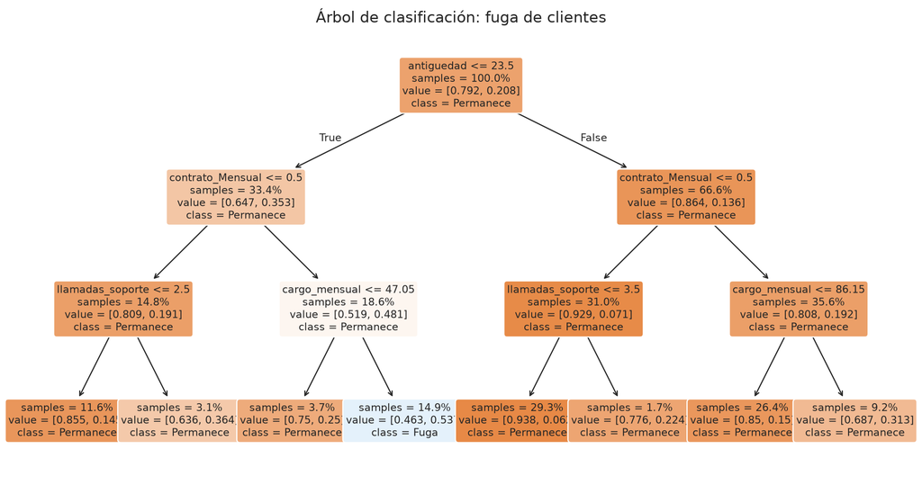

```python
arbol = DecisionTreeClassifier(max_depth=3, min_samples_leaf=50, random_state=2026)
arbol.fit(X_entrenamiento, y_entrenamiento)

fig, ax = plt.subplots(figsize=(14, 7))
plot_tree(
    arbol,
    feature_names=X_entrenamiento.columns,
    class_names=["Permanece", "Fuga"],
    filled=True,
    proportion=True,
    rounded=True,
    impurity=False,
    fontsize=9,
    ax=ax,
)
ax.set_title("Árbol de clasificación: fuga de clientes")
plt.show()
```

El árbol puede expresarse como **reglas de decisión** para comunicarlas a la gerencia. Cada regla describe una hoja, con la probabilidad de fuga de sus clientes y el porcentaje de clientes que cubre:

```python
def reglas_arbol(modelo, nombres_variables):
    arbol_ = modelo.tree_
    total = arbol_.n_node_samples[0]
    reglas = []

    def recorrer(nodo, condiciones):
        if arbol_.children_left[nodo] == -1:  # es una hoja
            reglas.append({
                "regla": " y ".join(condiciones),
                "prob_fuga": arbol_.value[nodo][0][1],
                "cobertura_pct": arbol_.n_node_samples[nodo] / total * 100,
            })
            return
        variable = nombres_variables[arbol_.feature[nodo]]
        umbral = arbol_.threshold[nodo]
        if variable.startswith("contrato_"):  # variable dummy
            izquierda = f"contrato ≠ {variable.removeprefix('contrato_')}"
            derecha = f"contrato = {variable.removeprefix('contrato_')}"
        else:
            izquierda, derecha = f"{variable} < {umbral:.1f}", f"{variable} ≥ {umbral:.1f}"
        recorrer(arbol_.children_left[nodo], condiciones + [izquierda])
        recorrer(arbol_.children_right[nodo], condiciones + [derecha])

    recorrer(0, [])
    return pd.DataFrame(reglas).sort_values("prob_fuga", ascending=False).round(3)


with pd.option_context("display.max_colwidth", None):
    display(reglas_arbol(arbol, list(X_entrenamiento.columns)))
```

|  | regla | prob_fuga | cobertura_pct |
| --- | --- | --- | --- |
| 3 | antiguedad < 23.5 y contrato = Mensual y cargo_mensual ≥ 47.0 | 0.537 | 14.943 |
| 1 | antiguedad < 23.5 y contrato ≠ Mensual y llamadas_soporte ≥ 2.5 | 0.364 | 3.143 |
| 7 | antiguedad ≥ 23.5 y contrato = Mensual y cargo_mensual ≥ 86.1 | 0.313 | 9.229 |
| 2 | antiguedad < 23.5 y contrato = Mensual y cargo_mensual < 47.0 | 0.250 | 3.657 |
| 5 | antiguedad ≥ 23.5 y contrato ≠ Mensual y llamadas_soporte ≥ 3.5 | 0.224 | 1.657 |
| 6 | antiguedad ≥ 23.5 y contrato = Mensual y cargo_mensual < 86.1 | 0.150 | 26.400 |
| 0 | antiguedad < 23.5 y contrato ≠ Mensual y llamadas_soporte < 2.5 | 0.145 | 11.629 |
| 4 | antiguedad ≥ 23.5 y contrato ≠ Mensual y llamadas_soporte < 3.5 | 0.062 | 29.343 |

La versión en texto del árbol completo se obtiene con `export_text`:

```python
print(export_text(arbol, feature_names=list(X_entrenamiento.columns), decimals=1))
```

```
|--- antiguedad <= 23.5
|   |--- contrato_Mensual <= 0.5
|   |   |--- llamadas_soporte <= 2.5
|   |   |   |--- class: 0
|   |   |--- llamadas_soporte >  2.5
|   |   |   |--- class: 0
|   |--- contrato_Mensual >  0.5
|   |   |--- cargo_mensual <= 47.0
|   |   |   |--- class: 0
|   |   |--- cargo_mensual >  47.0
|   |   |   |--- class: 1
|--- antiguedad >  23.5
|   |--- contrato_Mensual <= 0.5
|   |   |--- llamadas_soporte <= 3.5
|   |   |   |--- class: 0
|   |   |--- llamadas_soporte >  3.5
|   |   |   |--- class: 0
|   |--- contrato_Mensual >  0.5
|   |   |--- cargo_mensual <= 86.1
|   |   |   |--- class: 0
|   |   |--- cargo_mensual >  86.1
|   |   |   |--- class: 0
```

## 2.5 Random forest

```python
bosque = RandomForestClassifier(
    n_estimators=300,
    min_samples_leaf=20,
    oob_score=True,
    random_state=2026,
    n_jobs=-1,
)
bosque.fit(X_entrenamiento, y_entrenamiento)
print(f"Error OOB: {1 - bosque.oob_score_:.3f}")
```

```
Error OOB: 0.177
```

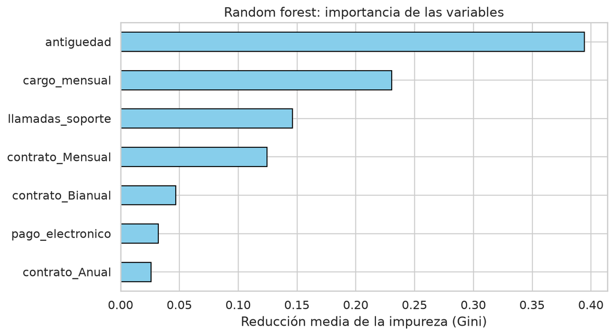

```python
importancia = pd.Series(bosque.feature_importances_, index=X_entrenamiento.columns).sort_values()

fig, ax = plt.subplots(figsize=(9, 5))
importancia.plot.barh(color="skyblue", edgecolor="black", ax=ax)
ax.set_title("Random forest: importancia de las variables")
ax.set_xlabel("Reducción media de la impureza (Gini)")
plt.show()
```

## 2.6 Comparación de modelos

Se calculan las métricas en el **conjunto de prueba**, con el umbral de 0.5.

```python
probabilidades = {
    "Logit": logit.predict(prueba).to_numpy(),
    "Árbol": arbol.predict_proba(X_prueba)[:, 1],
    "Random forest": bosque.predict_proba(X_prueba)[:, 1],
}


def calcular_metricas(y, p, umbral=0.5):
    pred = (p >= umbral).astype(int)
    vn, fp, _, _ = confusion_matrix(y, pred, labels=[0, 1]).ravel()
    return {
        "Exactitud": accuracy_score(y, pred),
        "Precisión": precision_score(y, pred, zero_division=0),
        "Sensibilidad": recall_score(y, pred),
        "Especificidad": vn / (vn + fp),
        "F1": f1_score(y, pred),
        "AUC": roc_auc_score(y, p),
    }


metricas = pd.DataFrame(
    {modelo: calcular_metricas(y_prueba, p) for modelo, p in probabilidades.items()}
).T.rename_axis("Modelo")

mejor_modelo = metricas["AUC"].idxmax()

metricas.round(3)
```

| Modelo | Exactitud | Precisión | Sensibilidad | Especificidad | F1 | AUC |
| --- | --- | --- | --- | --- | --- | --- |
| Logit | 0.813 | 0.601 | 0.304 | 0.947 | 0.403 | 0.803 |
| Árbol | 0.792 | 0.502 | 0.348 | 0.909 | 0.411 | 0.724 |
| Random forest | 0.814 | 0.642 | 0.246 | 0.964 | 0.356 | 0.798 |

El modelo con mayor AUC es **Logit**. Un modelo más complejo no siempre predice mejor: cuando la relación entre las variables y el *log-odds* de fuga es casi lineal, el logit compite de igual a igual con el random forest. Con el umbral de 0.5 la **sensibilidad es baja** (se detecta una minoría de los clientes que se van), lo que motiva revisar el umbral.

## 2.7 Matriz de confusión y curva ROC

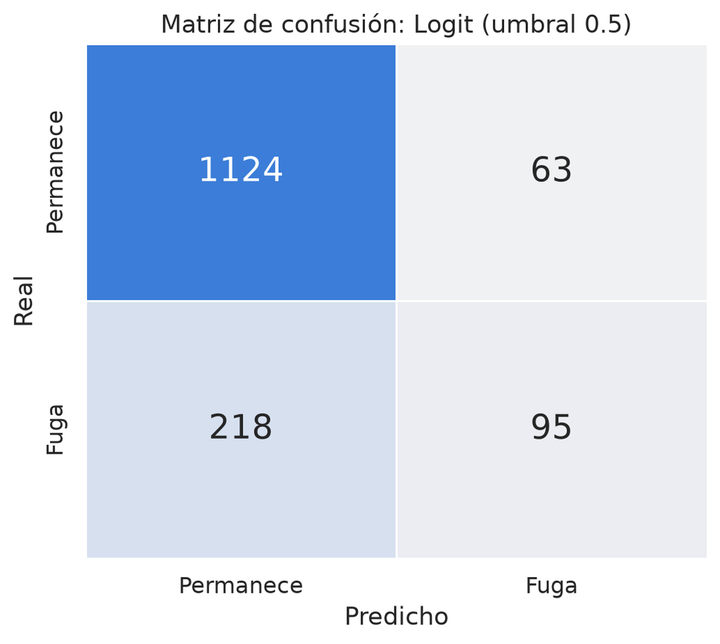

```python
etiquetas = ["Permanece", "Fuga"]
mc = pd.DataFrame(
    confusion_matrix(y_prueba, (probabilidades[mejor_modelo] >= 0.5).astype(int)),
    index=pd.Index(etiquetas, name="Real"),
    columns=pd.Index(etiquetas, name="Predicho"),
)

fig, ax = plt.subplots(figsize=(6, 5))
sns.heatmap(
    mc,
    annot=True,
    fmt="d",
    cmap=sns.light_palette("#3b7dd8", as_cmap=True),
    cbar=False,
    linewidths=1,
    annot_kws={"size": 18},
    ax=ax,
)
ax.set_title(f"Matriz de confusión: {mejor_modelo} (umbral 0.5)")
plt.show()
```

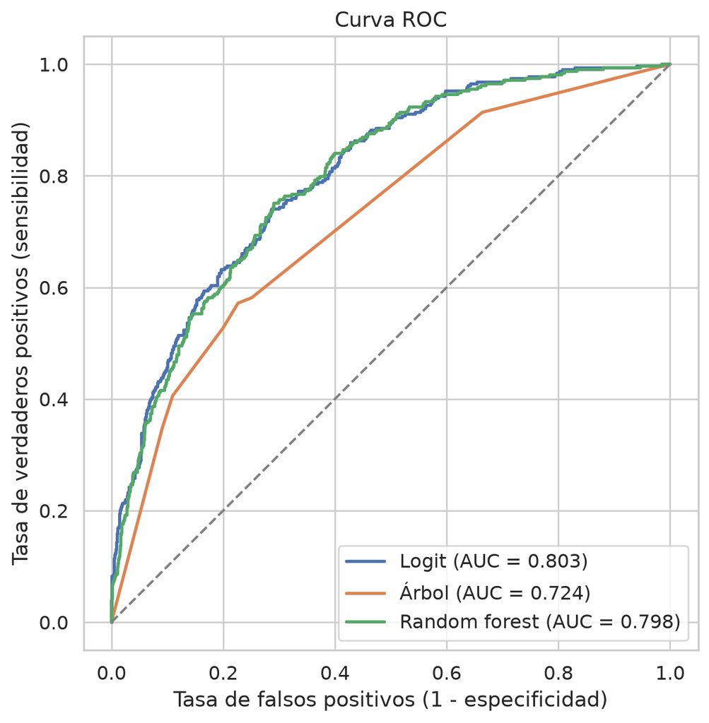

```python
fig, ax = plt.subplots(figsize=(8, 7))
for modelo, p in probabilidades.items():
    fpr, tpr, _ = roc_curve(y_prueba, p)
    ax.plot(fpr, tpr, linewidth=2, label=f"{modelo} (AUC = {roc_auc_score(y_prueba, p):.3f})")
ax.plot([0, 1], [0, 1], linestyle="--", color="gray")
ax.set_aspect("equal")
ax.set_title("Curva ROC")
ax.set_xlabel("Tasa de falsos positivos (1 - especificidad)")
ax.set_ylabel("Tasa de verdaderos positivos (sensibilidad)")
ax.legend(loc="lower right")
plt.show()
```

## 2.8 Elegir el umbral

Supuestos de la campaña: contactar a un cliente cuesta **USD 20** y retener a un cliente que se iba a fugar vale **USD 100**.

$$\text{Beneficio}(u) = 100 \cdot VP(u) - 20 \cdot \left[VP(u) + FP(u)\right]$$

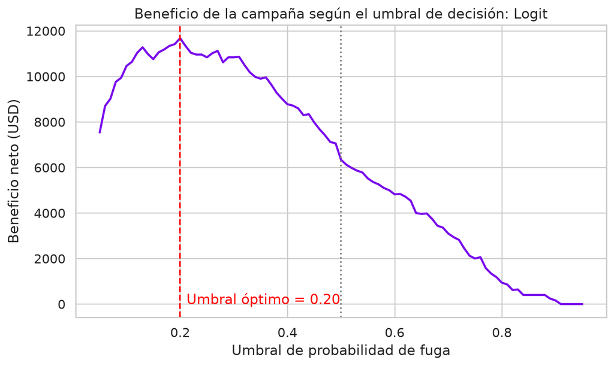

```python
p_mejor = probabilidades[mejor_modelo]
y_real = y_prueba.to_numpy() == 1

umbrales = np.round(np.arange(0.05, 0.951, 0.01), 2)
beneficio = pd.DataFrame({
    "umbral": umbrales,
    "contactados": [(p_mejor >= u).sum() for u in umbrales],
    "vp": [((p_mejor >= u) & y_real).sum() for u in umbrales],
})
beneficio["beneficio"] = 100 * beneficio["vp"] - 20 * beneficio["contactados"]

optimo = beneficio.loc[beneficio["beneficio"].idxmax()]
beneficio_05 = beneficio.loc[np.isclose(beneficio["umbral"], 0.5), "beneficio"].item()

fig, ax = plt.subplots(figsize=(9, 5))
ax.plot(beneficio["umbral"], beneficio["beneficio"], color="#790cee", linewidth=2)
ax.axvline(optimo["umbral"], color="red", linestyle="--")
ax.axvline(0.5, color="gray", linestyle=":")
ax.annotate(
    f"Umbral óptimo = {optimo['umbral']:.2f}",
    xy=(optimo["umbral"], beneficio["beneficio"].min()),
    xytext=(6, 0),
    textcoords="offset points",
    color="red",
)
ax.set_title(f"Beneficio de la campaña según el umbral de decisión: {mejor_modelo}")
ax.set_xlabel("Umbral de probabilidad de fuga")
ax.set_ylabel("Beneficio neto (USD)")
plt.show()
```

Con el umbral por defecto de 0.5 la campaña genera USD 6.340. Con el umbral óptimo de 0.20 se contacta a 576 clientes y el beneficio sube a USD 11.680. Como retener a un cliente vale cinco veces lo que cuesta contactarlo, conviene contactar a muchos más clientes de los que el umbral de 0.5 sugiere.

# 3 Caso 3. Segmentación de clientes (RFM)

El área de marketing de una cadena de retail quiere diseñar acciones diferenciadas según el comportamiento de compra de sus clientes: **recencia**, **frecuencia** y **ticket promedio**.

## 3.1 Datos

```python
retail = pd.read_csv("datos/retail_rfm.csv")
retail.drop(columns="id_cliente").describe().round(1)
```

|  | recencia | frecuencia | ticket_promedio |
| --- | --- | --- | --- |
| count | 2000.0 | 2000.0 | 2000.0 |
| mean | 94.2 | 10.2 | 87.9 |
| std | 94.9 | 8.1 | 58.1 |
| min | 1.0 | 1.0 | 13.3 |
| 25% | 27.0 | 3.0 | 44.5 |
| 50% | 50.0 | 8.0 | 62.3 |
| 75% | 150.0 | 15.0 | 127.2 |
| max | 365.0 | 40.0 | 293.3 |

## 3.2 Elegir el número de grupos

Se estandarizan las variables y se estima k-means para $k = 2, \dots, 8$, con 10 inicializaciones aleatorias cada uno (`n_init`).

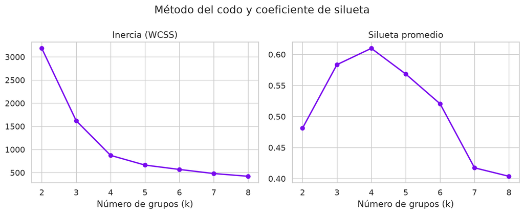

```python
variables_rfm = ["recencia", "frecuencia", "ticket_promedio"]
escalador = StandardScaler()
X_rfm = escalador.fit_transform(retail[variables_rfm])

filas = []
for k in range(2, 9):
    modelo = KMeans(n_clusters=k, n_init=10, random_state=2026).fit(X_rfm)
    filas.append({
        "k": k,
        "Inercia (WCSS)": modelo.inertia_,
        "Silueta promedio": silhouette_score(X_rfm, modelo.labels_),
    })
seleccion_k = pd.DataFrame(filas)

fig, axes = plt.subplots(1, 2, figsize=(11, 4.5))
for ax, criterio in zip(axes, ["Inercia (WCSS)", "Silueta promedio"]):
    ax.plot(seleccion_k["k"], seleccion_k[criterio], color="#790cee", linewidth=2, marker="o")
    ax.set_title(criterio)
    ax.set_xlabel("Número de grupos (k)")
fig.suptitle("Método del codo y coeficiente de silueta")
plt.tight_layout()
plt.show()
```

El codo aparece en $k = 4$, que también maximiza la silueta.

## 3.3 Estimación y perfil de los segmentos

```python
kmeans_rfm = KMeans(n_clusters=4, n_init=10, random_state=2026).fit(X_rfm)
retail["grupo"] = kmeans_rfm.labels_

# Nombrar los segmentos ordenándolos por recencia (de más a menos reciente)
nombres = ["Campeones", "Leales", "Ocasionales de alto ticket", "Inactivos"]

perfil = (
    retail.groupby("grupo")[variables_rfm].mean()
    .assign(clientes=retail.groupby("grupo").size())
    .assign(pct_clientes=lambda d: d["clientes"] / d["clientes"].sum() * 100)
    .sort_values("recencia")
    .assign(segmento=nombres)
)

retail["segmento"] = pd.Categorical(
    retail["grupo"].map(perfil["segmento"]), categories=nombres
)

perfil.set_index("segmento")[variables_rfm + ["clientes", "pct_clientes"]].round(1)
```

| segmento | recencia | frecuencia | ticket_promedio | clientes | pct_clientes |
| --- | --- | --- | --- | --- | --- |
| Campeones | 10.6 | 25.2 | 121.4 | 295 | 14.8 |
| Leales | 36.3 | 12.6 | 60.1 | 745 | 37.2 |
| Ocasionales de alto ticket | 71.7 | 5.2 | 184.7 | 393 | 19.7 |
| Inactivos | 229.3 | 2.9 | 39.7 | 567 | 28.4 |

## 3.4 Visualización de los segmentos

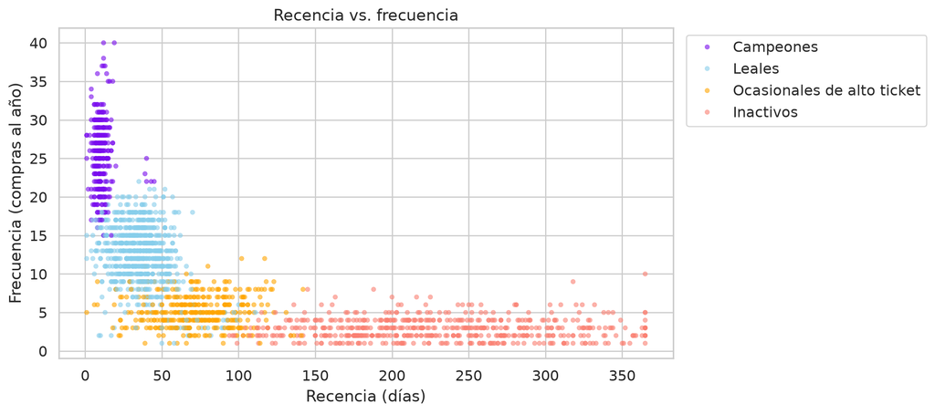

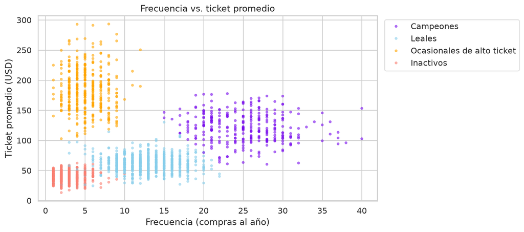

```python
colores = dict(zip(nombres, ["#790cee", "skyblue", "orange", "salmon"]))

for x, y, titulo, etiqueta_x, etiqueta_y in [
    ("recencia", "frecuencia", "Recencia vs. frecuencia",
     "Recencia (días)", "Frecuencia (compras al año)"),
    ("frecuencia", "ticket_promedio", "Frecuencia vs. ticket promedio",
     "Frecuencia (compras al año)", "Ticket promedio (USD)"),
]:
    fig, ax = plt.subplots(figsize=(11, 5))
    sns.scatterplot(
        data=retail, x=x, y=y, hue="segmento", palette=colores,
        s=14, alpha=0.6, edgecolor=None, ax=ax,
    )
    ax.set_title(titulo)
    ax.set_xlabel(etiqueta_x)
    ax.set_ylabel(etiqueta_y)
    ax.legend(title=None, bbox_to_anchor=(1.01, 1), loc="upper left")
    plt.tight_layout()
    plt.show()
```

## 3.5 Asignar un cliente nuevo

Un cliente nuevo se estandariza con la media y la desviación de los datos originales y se asigna al **centroide más cercano**.

```python
nuevo = pd.DataFrame({"recencia": [15], "frecuencia": [20], "ticket_promedio": [110]})

nuevo_z = escalador.transform(nuevo)
distancia_centroides = np.linalg.norm(kmeans_rfm.cluster_centers_ - nuevo_z, axis=1)

print(perfil.loc[distancia_centroides.argmin(), "segmento"])
```

```
Campeones
```

`KMeans` también lo resuelve directamente con `kmeans_rfm.predict(nuevo_z)`.

## 3.6 Acciones por segmento

| Segmento | Acción comercial sugerida |
| --- | --- |
| **Campeones** | Programa de fidelización, acceso anticipado a lanzamientos, embajadores de marca |
| **Leales** | Venta cruzada y venta adicional para subir el ticket |
| **Ocasionales de alto ticket** | Recordatorios personalizados y beneficios por recompra para aumentar la frecuencia |
| **Inactivos** | Campaña de reactivación de bajo costo; si no responden, reducir inversión |